# Fashion-MNIST with FCNs and Pytorch

## Author : Roshan Prakash Rane Date : 31st March 2020 #### Legend of the notebook :

green cells like this are used for providing results and analysis.

blue cells like this are used for providing info like design decisions and motivations.

yellow cells like this denote the start of a new subtask such as testing a new model variation.

#### Task breakdown :

1. Reaches ~95% accuracy on Fashion-MNIST
2. Test 3 models variations using different strategies, such that it
   1. increases accuracy
   2. reduces model size
   3. reduces inference time
3. Document
   1. time / space / accuracy complexity analysis of 3 models
   2. architecture specifications and models motivation
   3. cite used papers and provide motivation to use them
4. Show a demo of the model
5. Upload on git, git-pull and test </div>

## 1) Import libraries

```python
# standard python modules
import os, sys, glob
import numpy as np
import pandas as pd
from matplotlib import pyplot as plt

# PyTorch modules
import torch
import torch.nn as nn
import torch.nn.functional as F
import torch.optim as optim
from torch.nn.utils import clip_grad_value_

# import torchvision module to handle image manipulation
import torchvision
import torchvision.transforms as transforms

# misl imports
import time
import json
from collections  import OrderedDict, namedtuple
from itertools import product
from copy import deepcopy
from IPython.display import clear_output
```

```python
# set random seeds for reproducability
seed = 42
np.random.seed(seed)
torch.manual_seed(seed)
torch.backends.cudnn.deterministic = True

# GPU and random seed settings
GPU="3"
os.environ["CUDA_VISIBLE_DEVICES"] = GPU

# train on a GPU if available
device = "cuda" if torch.cuda.is_available() else "cpu"
```

## 2) Load dataset

```python
# Use standard FashionMNIST dataset
dataset = torchvision.datasets.FashionMNIST(
    root = './data/FashionMNIST',
    train = True,
    download = True,
    transform = transforms.Compose([
        transforms.ToTensor()]))

test_set = torchvision.datasets.FashionMNIST(
    root = './data/FashionMNIST',
    train = False,
    download = False,
    transform = transforms.Compose([
        transforms.ToTensor()]))

label_names = ["T-shirt/top","Trouser","Pullover","Dress","Coat","Sandal","Shirt","Sneaker","Bag","Ankle boot"]
```

```python
# split training data into training subset and validation subset
idxs = torch.randperm(len(dataset)).tolist()

train_set = torch.utils.data.Subset(dataset, idxs[:50000])
val_set = torch.utils.data.Subset(dataset, idxs[50000:])
print("Loaded Fashion-MNIST dataset with:\ntrain images\t{}  \nval images\t{}  \ntest images\t{}".format(len(train_set), len(val_set), len(test_set)))
```

```
Loaded Fashion-MNIST dataset with:
train images	50000
val images	10000
test images	10000
```

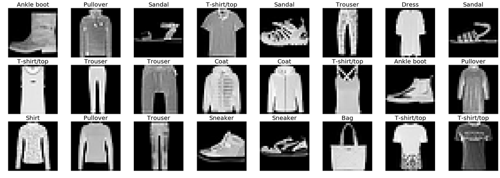

```python
# visualize some samples

dummy_dataloader = torch.utils.data.DataLoader(train_set, batch_size=24)
images, labels = next(iter(dummy_dataloader))
del dummy_dataloader

fig, axes = plt.subplots(nrows=3, ncols=8, figsize=(30,10))

for i, ax in enumerate(axes.reshape(-1)):
    ax.imshow(images[i,0], cmap="gray")
    ax.set_title(label_names[labels[i]], fontsize=20)
    ax.axis("off")

plt.subplots_adjust(wspace=0., hspace=0.15)
plt.show()
```

## 3) Training Helper Class

```python
class Trainer():
    '''Helper class to train neural network models'''
        # TODO explain arguments

    def __init__(
        self,
        net,
        train_data, val_data,
        batch_size, lr=0.01, lr_decay_every=10,
        l2_norm = 0,
        save_path="results/",
        device="cpu"):

        self.net = net
        self.batch_size = batch_size
        self.lr = lr

        self.save_path = save_path
        # clear output folder contents if it already exists
        if os.path.exists(self.save_path):
            os.system("rm -rf "+self.save_path)
        os.makedirs(self.save_path)

        # initialize the data loaders for training and validation
        self.train_loader = torch.utils.data.DataLoader(
            train_data, batch_size=self.batch_size, shuffle=True, num_workers=8)
        self.val_loader = torch.utils.data.DataLoader(
            val_data, batch_size=self.batch_size, num_workers=8)

        # ADAM optimizer with L2_norm regularization option
        self.optimizer = optim.Adam(self.net.parameters(), lr=self.lr, weight_decay=l2_norm)
        # learning rate scheduler: reduces by 10% every 'lr_decay_every' epochs
        self.scheduler = optim.lr_scheduler.LambdaLR(self.optimizer,
                                lambda e : (1-(0.1)*(e//lr_decay_every)) if (e//lr_decay_every)<10 else 0.1)

        #states that track loss, accuracy etc. Set some dummy values for epoch 0
        states_dict = OrderedDict([
             ("epoch duration",[0]), ("loss",[0.01]), ("val_loss",[0.01]),
             ("accuracy",[0.0]), ("val_accuracy",[0.0])
            ])
        self.results = pd.DataFrame.from_dict(states_dict)
        self.results.index.name = "epoch"
        self.n = 0


    def train(self):

        self.start_time = time.time()
        self.n += 1 # a count of how many times train() is called

        train_loss=0
        train_acc=0
        train_n=0
        # train from training split
        for images, labels in self.train_loader:
            images = images.to(device)
            labels = labels.to(device)
            preds = self.net(images)
            # calculate the loss using cross_entropy
            loss = F.cross_entropy(preds, labels)
            # back propagate the loss
            self.optimizer.zero_grad()
            loss.backward()
            # clip gradients to avoid exploding gradients
            clip_grad_value_(self.net.parameters(), 0.1)
            self.optimizer.step()

            train_loss =+ loss.item()
            train_acc =+ self.equals(preds, labels)
            train_n =+ len(images)

        self.net.eval()
        val_loss=0
        val_acc=0
        val_n=0

        with torch.no_grad():
            for images, labels in self.val_loader:
                images = images.to(device)
                labels = labels.to(device)
                preds = self.net(images)
                val_loss = F.cross_entropy(preds, labels)

                val_loss =+ val_loss.item()
                val_acc =+ self.equals(preds, labels)
                val_n =+ len(images)

        self.scheduler.step()
        epoch_duration = time.time() - self.start_time

        # calculate all the scores at the end of an epoch and store it
        result = OrderedDict()
        result["epoch duration"] = epoch_duration
        result["loss"] = train_loss/train_n
        result["val_loss"] = val_loss/val_n
        result["accuracy"] = round(100*train_acc/train_n,2) # in percentage
        result["val_accuracy"] = round(100*val_acc/val_n,2) # in percentage
        self.results.loc[self.n] = result

        self.net.train()

    def end(self):
        # save training history
        self.results.to_csv(self.save_path+"results.csv")
        # plot and save the training curves
        self.plot_training_curves()
        plt.savefig(self.save_path+"training_curve.png")
        plt.suptitle(self.save_path.replace("/"," "))
        plt.show()
        # save the final model
        self.save_model("model-epoch{}".format(self.n))

    def save_model(self, fname="model"):
        # save model state to the path
        torch.save(self.net, self.save_path+fname+".pt")

    def load_model(self, path):
        # load a previously trained model from the path
        self.net.load_state_dict(path)

    def plot_training_curves(self):
        fig, (ax0, ax1) = plt.subplots(ncols=2, figsize=(12,4))
        # adhoc fix my clipping loss values to avoid a distorted graph when one epoch loss is abnormally high
        self.results.loss[self.results.loss>0.01] = 0.01
        self.results.val_loss[self.results.val_loss>0.01] = 0.01
        self.results.plot(y=['loss','val_loss'], title="loss", grid=True, ax=ax0)
        self.results.plot(
            y=['accuracy','val_accuracy'], title="Classification accuracy (%)",
            grid=True, ylim=[0,100], ax=ax1)

    def equals(self, preds, labels):
        count = preds.argmax(dim=1).eq(labels).sum().item()
        return count
```

## 4) Architecture

### A Fully-convolutional network (FCN) with Batch-Norm and ELU activations. Design Decision : _FCNs have only covolutional layers instead of fully-connected layers in the end of the network (like AlexNet). A FCN (https://arxiv.org/abs/1411.4038) is chosen over a traditional CNN because they can be dynamically configurable for changing image sizes while being mathematically equivalent to traditional CNN._ Design Decision : _Each layer of the network comprises of 2 blocks of **Convolution-BatchNorm-ELU**. The first block uses same-padding while the second has zero-padding for convinience of model design._ Design Decision : _The Elu() activation is used instead of the popular ReLu activation since it is more capable of handling vanishing gradient problems while having comparable performance to ReLu_ The architectures can be further visualized in later cells of the notebook where this class is initialized.

```python
class FCN(nn.Module):

    def __init__(self, in_shape=(1,28,28), out_classes=10,
                 kernel_size=3, convs=[6,12], dropout=0,
                 debug_print=False):

        # TODO explain args
        super().__init__()

        in_chns, in_h, in_w = in_shape
        self.out_classes = out_classes
        self.k = kernel_size
        assert self.k%2==1, "kernel_size must be odd numbers like 3,5,7 for this architecture to dynamically be configured."
        self.debug_print = debug_print
        self.dropout = dropout

        # build the convolutional layers
        self.convs = nn.ModuleList([])
        out_h, out_w = (in_h, in_w)

        for cin, cout in zip([in_chns]+convs, convs):
            layers = []
            # add dropout layer if requested
            if self.dropout : layers.append(nn.Dropout2d(p=dropout))

            # add 2 convolution layer with provided kernel_size , batch Norm and ELU activations
            # number of intermediary channels calculated dynamically
            cmid = cin + (cout-cin)//2
            layers.extend([nn.Conv2d(cin, cmid, kernel_size=self.k, padding=(self.k-1)//2), # full padding
                           nn.BatchNorm2d(cmid),
                           nn.ELU(),
                           nn.Conv2d(cmid, cout, kernel_size=self.k, padding=0), # zero padding
                           nn.BatchNorm2d(cout),
                           nn.ELU()
                          ])

            self.convs.append(nn.Sequential(*layers))
            # dynamically calculate the output shape of convolutions + pooling (without padding)
            # equations taken from https://medium.com/mlreview/a-guide-to-receptive-field-arithmetic-for-convolutional-neural-networks-e0f514068807
            out_h = (out_h-self.k+1)//2
            out_w = (out_w-self.k+1)//2
            if self.debug_print: print((out_h,out_w))
            assert out_h > 0 and out_w > 0

        # set the last FCN layer kernel_size such that it produces a single output prediction
        self.finalconv = nn.Conv2d(convs[-1], self.out_classes, kernel_size=(out_h,out_w))


    def forward(self, t):

        # loop over all convolution layers
        for i,conv in enumerate(self.convs):

            # 2 X covolution + non-linear Elu operation
            t = conv(t)
            if self.debug_print: print("conv{}>{}".format(i,list(t.shape)))

            # perform maxpool with (2x2) kernels
            t = F.max_pool2d(t, kernel_size=2, stride=2)
            if self.debug_print: print("pool{}>{}".format(i,list(t.shape)))

        # final layer
        t = self.finalconv(t)

        # no activations in the last layer since we use cross_entropy_loss with logits
        t = t.reshape(-1,self.out_classes)

        if self.debug_print:
            print("final{}>{}".format(i,list(t.shape)))
            self.debug_print = False

        return t
```

```python
# helper function that counts the parameters in a model
def count_parameters(model):
    return sum(p.numel() for p in model.parameters() if p.requires_grad)

# helper function that randomly inits the weights of the model
def init_weights(m):
    if isinstance(m, torch.nn.Conv2d) or isinstance(m, torch.nn.Linear):
        torch.nn.init.xavier_uniform_(m.weight)
        if hasattr(m, "bias") and m.bias is not None:
            torch.nn.init.zeros_(m.bias)
```

## 4) Experiments

```python
# Init the hyperparams and tune the hyperparameter settings on model 0 performance
lr = .01
batch_size = 512
epochs = 100
lr_decay_every = 8
max_patience = 20
model_scores = {}
```

## Model 0: Baseline

```python
# init the Model
model_0 = FCN(convs=[16,32,64], kernel_size=3, debug_print=False).to(device)
print("MODEL0 ({} parameters)::\n{}".format(count_parameters(model_0), model_0))
```

```
MODEL0 (54290 parameters)::
FCN(
  (convs): ModuleList(
    (0): Sequential(
      (0): Conv2d(1, 8, kernel_size=(3, 3), stride=(1, 1), padding=(1, 1))
      (1): BatchNorm2d(8, eps=1e-05, momentum=0.1, affine=True, track_running_stats=True)
      (2): ELU(alpha=1.0)
      (3): Conv2d(8, 16, kernel_size=(3, 3), stride=(1, 1))
      (4): BatchNorm2d(16, eps=1e-05, momentum=0.1, affine=True, track_running_stats=True)
      (5): ELU(alpha=1.0)
    )
    (1): Sequential(
      (0): Conv2d(16, 24, kernel_size=(3, 3), stride=(1, 1), padding=(1, 1))
      (1): BatchNorm2d(24, eps=1e-05, momentum=0.1, affine=True, track_running_stats=True)
      (2): ELU(alpha=1.0)
      (3): Conv2d(24, 32, kernel_size=(3, 3), stride=(1, 1))
      (4): BatchNorm2d(32, eps=1e-05, momentum=0.1, affine=True, track_running_stats=True)
      (5): ELU(alpha=1.0)
    )
    (2): Sequential(
      (0): Conv2d(32, 48, kernel_size=(3, 3), stride=(1, 1), padding=(1, 1))
      (1): BatchNorm2d(48, eps=1e-05, momentum=0.1, affine=True, track_running_stats=True)
      (2): ELU(alpha=1.0)
      (3): Conv2d(48, 64, kernel_size=(3, 3), stride=(1, 1))
      (4): BatchNorm2d(64, eps=1e-05, momentum=0.1, affine=True, track_running_stats=True)
      (5): ELU(alpha=1.0)
    )
  )
  (finalconv): Conv2d(64, 10, kernel_size=(1, 1), stride=(1, 1))
)
```

```python
# randomly initialize the weights of the model
model_0 = model_0.apply(init_weights)
trainer = Trainer(model_0, train_set, val_set,
                  batch_size=batch_size, lr=lr, lr_decay_every=lr_decay_every,
                  save_path="results-model_0/",
                  device=device)
```

Design decision: _The Early stopping mechanism is implemented to keep a check on over-fitting_ _To design my early stopping algorithm, I use the analysis of Lutz Prechelt(http://page.mi.fu-berlin.de/prechelt/Biblio/stop_tricks1997.pdf). I set the stopping criteria as a moving-average of validation accuracy in the last 2 epochs to avoid stopping because of jitters in learning curve.

| epoch | epoch duration | loss | val_loss | accuracy | val_accuracy |
| --- | --- | --- | --- | --- | --- |
| 0 | 0.000000 | 1.000000e-02 | 0.010000 | 0.00 | 0.00 |
| 1 | 5.541614 | 8.899028e-04 | 0.001717 | 89.58 | 83.09 |
| 2 | 5.540756 | 9.196959e-04 | 0.001412 | 88.69 | 84.56 |
| 3 | 5.641074 | 8.099546e-04 | 0.000992 | 89.88 | 88.97 |
| 4 | 5.572558 | 8.551351e-04 | 0.001043 | 89.58 | 88.60 |
| 5 | 5.293799 | 6.889465e-04 | 0.001026 | 89.58 | 91.54 |
| 6 | 5.560313 | 6.669156e-04 | 0.000948 | 91.07 | 89.71 |
| 7 | 5.469646 | 6.544510e-04 | 0.001172 | 91.67 | 88.24 |
| 8 | 5.505976 | 5.360204e-04 | 0.000873 | 93.75 | 90.81 |
| 9 | 5.565526 | 3.946741e-04 | 0.000885 | 95.83 | 90.07 |
| 10 | 5.596758 | 3.683672e-04 | 0.001081 | 94.05 | 87.50 |
| 11 | 5.575381 | 5.176690e-04 | 0.000950 | 94.05 | 89.71 |
| 12 | 5.378288 | 4.190716e-04 | 0.001087 | 94.94 | 89.71 |
| 13 | 5.459559 | 4.057865e-04 | 0.000999 | 95.83 | 90.07 |
| 14 | 5.380993 | 4.004411e-04 | 0.001208 | 95.24 | 88.24 |
| 15 | 5.395710 | 3.362592e-04 | 0.001050 | 95.24 | 90.81 |
| 16 | 5.430677 | 3.515570e-04 | 0.001277 | 94.05 | 91.91 |
| 17 | 5.616569 | 1.198739e-04 | 0.001215 | 99.11 | 88.97 |
| 18 | 5.567147 | 3.632046e-04 | 0.001084 | 94.94 | 91.18 |
| 19 | 5.563650 | 1.895875e-04 | 0.001505 | 97.62 | 88.97 |
| 20 | 5.510020 | 3.832647e-04 | 0.001410 | 95.24 | 90.44 |
| 21 | 5.488258 | 1.533093e-04 | 0.001689 | 97.62 | 90.44 |
| 22 | 5.533358 | 3.003014e-04 | 0.001332 | 96.43 | 88.60 |
| 23 | 5.480976 | 1.396924e-04 | 0.001179 | 98.81 | 90.44 |
| 24 | 5.609213 | 8.410800e-05 | 0.001583 | 99.11 | 91.18 |
| 25 | 5.516921 | 5.545035e-05 | 0.001572 | 99.40 | 90.07 |
| 26 | 5.357614 | 6.920384e-05 | 0.001511 | 98.81 | 91.54 |
| 27 | 5.549115 | 6.558518e-05 | 0.001461 | 99.11 | 92.28 |
| 28 | 5.540297 | 1.856796e-05 | 0.001635 | 100.00 | 90.07 |
| 29 | 5.577180 | 3.033081e-05 | 0.001757 | 99.70 | 90.07 |
| 30 | 5.572620 | 2.265220e-05 | 0.001495 | 100.00 | 91.18 |
| 31 | 5.485283 | 1.342104e-04 | 0.002036 | 98.51 | 89.71 |
| 32 | 5.337556 | 1.188069e-04 | 0.001654 | 97.62 | 91.18 |
| 33 | 5.468025 | 1.133551e-04 | 0.001846 | 98.51 | 89.71 |
| 34 | 5.550770 | 5.067757e-05 | 0.001472 | 99.40 | 91.54 |
| 35 | 5.507160 | 1.348250e-05 | 0.001762 | 100.00 | 91.91 |
| 36 | 5.417572 | 1.109005e-05 | 0.001562 | 100.00 | 91.54 |
| 37 | 4.642811 | 3.207040e-06 | 0.001578 | 100.00 | 91.54 |
| 38 | 4.699472 | 1.703514e-06 | 0.001543 | 100.00 | 91.18 |
| 39 | 4.938729 | 1.299645e-06 | 0.001602 | 100.00 | 91.54 |
| 40 | 4.775969 | 1.419589e-06 | 0.001605 | 100.00 | 91.54 |
| 41 | 4.564546 | 1.262797e-06 | 0.001605 | 100.00 | 91.54 |
| 42 | 4.880316 | 9.581409e-07 | 0.001613 | 100.00 | 91.54 |
| 43 | 4.792553 | 1.021346e-06 | 0.001635 | 100.00 | 91.54 |
| 44 | 4.768004 | 9.180391e-07 | 0.001670 | 100.00 | 91.54 |
| 45 | 4.761573 | 8.526121e-07 | 0.001680 | 100.00 | 91.54 |
| 46 | 4.831316 | 4.808328e-07 | 0.001673 | 100.00 | 91.18 |
| 47 | 4.844336 | 5.468975e-07 | 0.001711 | 100.00 | 91.18 |
| 48 | 4.587654 | 6.084641e-07 | 0.001720 | 100.00 | 91.18 |

```
Stopping at epoch 26.
Best validation accuracy = 91.91%
```

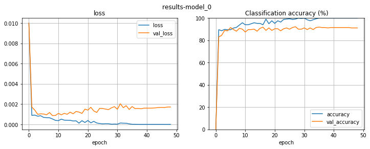

```python
best_val_acc = 0
best_epoch = 0
patience = 0

for epoch in range(epochs):
    # train the model
    trainer.train()

    # display the results so far on iPython console
    clear_output(wait=True)
    display(trainer.results)

    # create a model checkpoint if needed
    cur_val_acc = trainer.results.val_accuracy.iloc[-2:].mean()
    if  cur_val_acc > best_val_acc:
        best_epoch = epoch
        best_val_acc = cur_val_acc
        trainer.save_model("model_best")
        # reset patience
        patience = 0
    else:
        patience += 1

    # early stop if the validation accuracy didnt improve for 5 epochs
    if patience > max_patience:
        break

print("Stopping at epoch {}. \nBest validation accuracy = {}%".format(
    best_epoch, best_val_acc))
# at the end plot training curves, save results and model to files
trainer.end()
```

## MODEL 1: Perform data augumentations 1. Random flip : horizontal flip, vertical flip 2. Random crop and resize 3. Random image Jitters : change brightness and contrast

```python
#  resample training set with data augumentations
dataset = torchvision.datasets.FashionMNIST(
    root = './data/FashionMNIST',
    train = True,
    transform = transforms.Compose([
        transforms.RandomHorizontalFlip(p=0.5),
        transforms.RandomVerticalFlip(p=0.2),
        transforms.RandomResizedCrop((28,28), scale=(0.8, 1.0), ratio=(0.75, 1.25)),
        transforms.ColorJitter(brightness=[0.8,1], contrast=[0.8,1], saturation=0, hue=0),
        transforms.ToTensor()
    ]))
train_set = torch.utils.data.Subset(dataset, idxs[:50000])
```

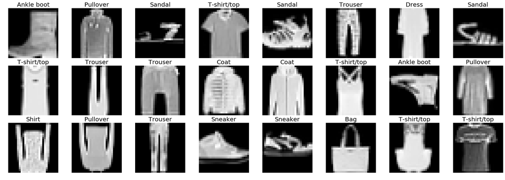

```python
# visualize some samples after augumentation
dummy_dataloader = torch.utils.data.DataLoader(train_set, batch_size=24)
images, labels = next(iter(dummy_dataloader))
del dummy_dataloader

fig, axes = plt.subplots(nrows=3, ncols=8, figsize=(30,10))

for i, ax in enumerate(axes.reshape(-1)):
    ax.imshow(images[i,0], cmap="gray")
    ax.set_title(label_names[labels[i]], fontsize=20)
    ax.axis("off")

plt.subplots_adjust(wspace=0., hspace=0.15)
plt.show()
```

```python
# reset the model_0 weights
model_1 = model_0.apply(init_weights)

trainer = Trainer(model_0, train_set, val_set,
                  batch_size=batch_size, lr=lr, lr_decay_every=lr_decay_every,
                  save_path="results-model_1/",
                  device=device)
```

| epoch | epoch duration | loss | val_loss | accuracy | val_accuracy |
| --- | --- | --- | --- | --- | --- |
| 0 | 0.000000 | 0.010000 | 0.010000 | 0.00 | 0.00 |
| 1 | 6.707825 | 0.001403 | 0.001684 | 80.95 | 82.35 |
| 2 | 6.621151 | 0.001239 | 0.001408 | 88.10 | 84.56 |
| 3 | 6.907953 | 0.001164 | 0.001871 | 85.42 | 82.35 |
| 4 | 6.827749 | 0.001193 | 0.001242 | 83.93 | 87.13 |
| 5 | 6.696263 | 0.000902 | 0.001263 | 88.39 | 86.03 |
| 6 | 6.926018 | 0.001231 | 0.001087 | 84.23 | 88.24 |
| 7 | 6.902843 | 0.000980 | 0.001267 | 87.50 | 87.50 |
| 8 | 6.660229 | 0.001004 | 0.001302 | 86.31 | 88.24 |
| 9 | 6.886789 | 0.000934 | 0.000931 | 88.10 | 91.18 |
| 10 | 6.779661 | 0.001137 | 0.001048 | 84.23 | 89.71 |
| 11 | 6.809228 | 0.000785 | 0.001058 | 90.77 | 89.34 |
| 12 | 6.906694 | 0.000739 | 0.000934 | 90.77 | 90.81 |
| 13 | 6.696205 | 0.000896 | 0.000998 | 87.80 | 89.71 |
| 14 | 6.906577 | 0.000958 | 0.000966 | 88.10 | 90.44 |
| 15 | 6.740519 | 0.000645 | 0.000921 | 93.15 | 89.71 |
| 16 | 7.056664 | 0.000810 | 0.000964 | 90.18 | 90.81 |
| 17 | 7.265858 | 0.000704 | 0.000797 | 91.37 | 91.91 |
| 18 | 7.006635 | 0.000581 | 0.000888 | 91.96 | 89.71 |
| 19 | 7.180718 | 0.000830 | 0.000841 | 89.58 | 91.18 |
| 20 | 7.046243 | 0.000766 | 0.000968 | 91.37 | 90.44 |
| 21 | 7.148595 | 0.000782 | 0.000795 | 89.88 | 90.81 |
| 22 | 6.931615 | 0.000734 | 0.000944 | 89.58 | 91.18 |
| 23 | 7.081059 | 0.001060 | 0.000833 | 87.50 | 90.07 |
| 24 | 7.019089 | 0.000759 | 0.000935 | 91.96 | 90.44 |
| 25 | 7.085750 | 0.000712 | 0.000762 | 91.37 | 90.44 |
| 26 | 7.453222 | 0.000834 | 0.000741 | 86.61 | 91.18 |
| 27 | 6.983192 | 0.000627 | 0.000689 | 92.56 | 91.91 |
| 28 | 6.935143 | 0.000560 | 0.000708 | 92.86 | 93.38 |
| 29 | 6.974546 | 0.000793 | 0.000885 | 90.48 | 91.54 |
| ... | ... | ... | ... | ... | ... |
| 42 | 6.918947 | 0.000542 | 0.000773 | 91.96 | 92.65 |
| 43 | 7.110540 | 0.000622 | 0.000804 | 92.26 | 90.81 |
| 44 | 6.816939 | 0.000675 | 0.000712 | 91.07 | 92.28 |
| 45 | 7.011669 | 0.000695 | 0.000655 | 92.26 | 92.28 |
| 46 | 6.966369 | 0.000787 | 0.000810 | 89.58 | 92.65 |
| 47 | 6.937099 | 0.000714 | 0.000653 | 90.48 | 92.65 |
| 48 | 7.197250 | 0.000509 | 0.000691 | 93.45 | 90.81 |
| 49 | 7.067255 | 0.000661 | 0.000654 | 91.96 | 94.49 |
| 50 | 7.146844 | 0.000568 | 0.000634 | 92.86 | 93.38 |
| 51 | 7.143538 | 0.000675 | 0.000752 | 90.77 | 93.75 |
| 52 | 7.024579 | 0.000581 | 0.000748 | 91.67 | 92.65 |
| 53 | 6.892802 | 0.000589 | 0.000738 | 91.96 | 93.01 |
| 54 | 6.494547 | 0.000415 | 0.000782 | 94.64 | 91.91 |
| 55 | 6.434109 | 0.000624 | 0.000704 | 91.67 | 93.38 |
| 56 | 6.433823 | 0.000520 | 0.000718 | 93.45 | 91.91 |
| 57 | 6.536035 | 0.000588 | 0.000795 | 94.05 | 91.91 |
| 58 | 6.423246 | 0.000347 | 0.000751 | 96.13 | 91.91 |
| 59 | 6.306206 | 0.000524 | 0.000755 | 93.75 | 92.28 |
| 60 | 6.461222 | 0.000649 | 0.000793 | 92.26 | 91.18 |
| 61 | 6.473109 | 0.000483 | 0.000656 | 93.45 | 93.75 |
| 62 | 6.440840 | 0.000580 | 0.000802 | 91.67 | 92.65 |
| 63 | 6.561531 | 0.000576 | 0.000775 | 91.07 | 91.54 |
| 64 | 6.390406 | 0.000504 | 0.000758 | 94.64 | 92.28 |
| 65 | 6.494934 | 0.000542 | 0.000683 | 94.35 | 93.38 |
| 66 | 6.492651 | 0.000758 | 0.000692 | 91.37 | 93.75 |
| 67 | 6.546235 | 0.000480 | 0.000673 | 93.75 | 93.75 |
| 68 | 6.485149 | 0.000484 | 0.000709 | 94.05 | 92.65 |
| 69 | 6.469836 | 0.000394 | 0.000683 | 94.35 | 93.38 |
| 70 | 6.538481 | 0.000439 | 0.000640 | 94.05 | 92.65 |
| 71 | 6.661997 | 0.000493 | 0.000628 | 94.35 | 94.12 |

72 rows × 5 columns

```
Stopping at epoch 49.
Best validation accuracy = 93.935%
```

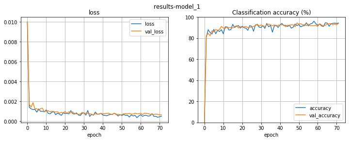

```python
best_val_acc = 0
best_epoch = 0
patience = 0

for epoch in range(epochs):
    # train the model
    trainer.train()

    # display the results so far on iPython console
    clear_output(wait=True)
    display(trainer.results)

    # create a model checkpoint if needed
    cur_val_acc = trainer.results.val_accuracy.iloc[-2:].mean()
    if  cur_val_acc > best_val_acc :
        best_epoch = epoch
        best_val_acc = cur_val_acc
        trainer.save_model("model_best")
        # reset patience
        patience = 0
    else:
        patience += 1

    # early stop if the validation accuracy didnt improve for 'patience' epochs
    if patience > max_patience:
        break

# save the best results for later comparison
model_scores.update({
    "model_1":{
         "accuracy":best_val_acc,
         "parameters":count_parameters(model_1),
         "latency":trainer.results["epoch duration"].mean(),
        }})

print("Stopping at epoch {}. \nBest validation accuracy = {}%".format(
    best_epoch, best_val_acc))
# at the end plot training curves, save results and model to files
trainer.end()
```

## Analysis of Model 1 (data augumentation) As observed from the training curve above, the added data augumentations result in a drop in the training accuracy. However, the validation accuracy and hence the generalization of the network improves. **Therefore, data augumentation is beneficial and retained for the next experiments**

Model architecture is denoted here as a list for simplicity. Length of the list represents the depth of the network and each number represents the number of output channels of that layer. For example, the above baseline model can be represented as [16, 32, 64, final_Conv1x1]

## MODEL 2: Test different model capacities Test different variations of the baseline model by changing the depth and channels-per-layer : 1. [32, 64, final_Conv4x4] , kernel_size = (5x5) 2. [32, 64, 128, final_Conv1x1] , kernel_size = (3x3) 3. [64, 128, final_Conv4x4] , kernel_size = (5x5) 4. [64, 128, 256, final_Conv1x1] , kernel_size = (3x3) 5. [128, 256, final_Conv4x4] , kernel_size = (5x5)

```python
# init the different model architectures
model_2s = OrderedDict((
    ("model_2a" , FCN(convs=[32,64], kernel_size=5).to(device)),
    ("model_2b" , FCN(convs=[32,64,128], kernel_size=3).to(device)),
    ("model_2c" , FCN(convs=[64,128], kernel_size=5).to(device)),
    ("model_2d" , FCN(convs=[64,128,256], kernel_size=3).to(device)),
    ("model_2e" , FCN(convs=[128,256], kernel_size=5).to(device)),
))

# print the architectures and number of parameters
for name, model in model_2s.items():
    print("------------------------------\n{} ({} parameters)\n------------------------------\n{}\n".format(
        name.upper(), count_parameters(model), model))
```

```
------------------------------
MODEL_2A (139130 parameters)
------------------------------
FCN(
  (convs): ModuleList(
    (0): Sequential(
      (0): Conv2d(1, 16, kernel_size=(5, 5), stride=(1, 1), padding=(2, 2))
      (1): BatchNorm2d(16, eps=1e-05, momentum=0.1, affine=True, track_running_stats=True)
      (2): ELU(alpha=1.0)
      (3): Conv2d(16, 32, kernel_size=(5, 5), stride=(1, 1))
      (4): BatchNorm2d(32, eps=1e-05, momentum=0.1, affine=True, track_running_stats=True)
      (5): ELU(alpha=1.0)
    )
    (1): Sequential(
      (0): Conv2d(32, 48, kernel_size=(5, 5), stride=(1, 1), padding=(2, 2))
      (1): BatchNorm2d(48, eps=1e-05, momentum=0.1, affine=True, track_running_stats=True)
      (2): ELU(alpha=1.0)
      (3): Conv2d(48, 64, kernel_size=(5, 5), stride=(1, 1))
      (4): BatchNorm2d(64, eps=1e-05, momentum=0.1, affine=True, track_running_stats=True)
      (5): ELU(alpha=1.0)
    )
  )
  (finalconv): Conv2d(64, 10, kernel_size=(4, 4), stride=(1, 1))
)

------------------------------
MODEL_2B (214554 parameters)
------------------------------
FCN(
  (convs): ModuleList(
    (0): Sequential(
      (0): Conv2d(1, 16, kernel_size=(3, 3), stride=(1, 1), padding=(1, 1))
      (1): BatchNorm2d(16, eps=1e-05, momentum=0.1, affine=True, track_running_stats=True)
      (2): ELU(alpha=1.0)
      (3): Conv2d(16, 32, kernel_size=(3, 3), stride=(1, 1))
      (4): BatchNorm2d(32, eps=1e-05, momentum=0.1, affine=True, track_running_stats=True)
      (5): ELU(alpha=1.0)
    )
    (1): Sequential(
      (0): Conv2d(32, 48, kernel_size=(3, 3), stride=(1, 1), padding=(1, 1))
```

[output cut: 85 more lines]

```
      (3): Conv2d(64, 128, kernel_size=(5, 5), stride=(1, 1))
      (4): BatchNorm2d(128, eps=1e-05, momentum=0.1, affine=True, track_running_stats=True)
      (5): ELU(alpha=1.0)
    )
    (1): Sequential(
      (0): Conv2d(128, 192, kernel_size=(5, 5), stride=(1, 1), padding=(2, 2))
      (1): BatchNorm2d(192, eps=1e-05, momentum=0.1, affine=True, track_running_stats=True)
      (2): ELU(alpha=1.0)
      (3): Conv2d(192, 256, kernel_size=(5, 5), stride=(1, 1))
      (4): BatchNorm2d(256, eps=1e-05, momentum=0.1, affine=True, track_running_stats=True)
      (5): ELU(alpha=1.0)
    )
  )
  (finalconv): Conv2d(256, 10, kernel_size=(4, 4), stride=(1, 1))
)
```

```
------------------------------
Training MODEL_2A (139130 parameters)
----------------------------
Stopping at epoch 85.
Best validation accuracy = 95.405%
```

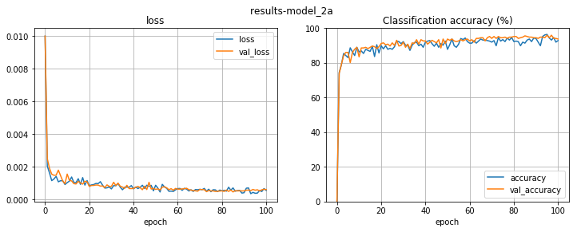

```
------------------------------
Training MODEL_2B (214554 parameters)
----------------------------
Stopping at epoch 75.
Best validation accuracy = 97.245%
```

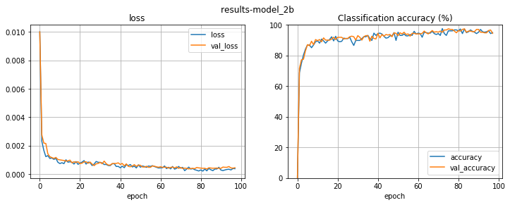

```
------------------------------
Training MODEL_2C (534250 parameters)
----------------------------
Stopping at epoch 49.
Best validation accuracy = 93.385%
```

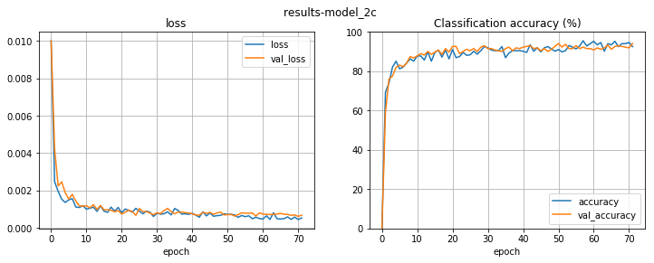

```
------------------------------
Training MODEL_2D (853034 parameters)
----------------------------
Stopping at epoch 86.
Best validation accuracy = 95.775%
```

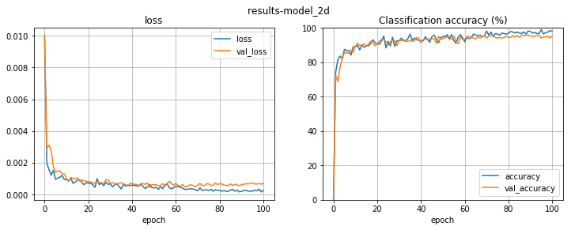

```
------------------------------
Training MODEL_2E (2092490 parameters)
----------------------------
Stopping at epoch 97.
Best validation accuracy = 96.505%
```

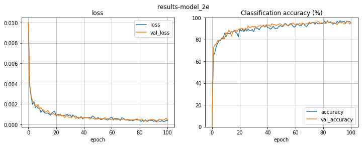

```python
# train the model variations
for name, model in model_2s.items():
    # init the trainer helper class and reset the model_weights
    model = model.apply(init_weights)
    trainer = Trainer(model, train_set, val_set,
                      batch_size=batch_size, lr=lr, lr_decay_every=lr_decay_every,
                      save_path="results-{}/".format(name),
                      device=device)
    # train
    print("------------------------------\nTraining {} ({} parameters)\n----------------------------".format(
        name.upper(), count_parameters(model)))
    best_val_acc = 0
    best_epoch = 0
    patience = 0
    for epoch in range(epochs):
        trainer.train()
        # create a model checkpoint if needed
        cur_val_acc = trainer.results.val_accuracy.iloc[-2:].mean()
        if  cur_val_acc > best_val_acc:
            best_epoch = epoch
            best_val_acc = cur_val_acc
            trainer.save_model("model_best")
            # reset patience
            patience = 0
        else:
            patience += 1
        # early stop if the validation accuracy didnt improve for 5 epochs
        if patience > max_patience:
            break

    model_scores.update({
        name:{
         "accuracy":best_val_acc,
         "parameters":count_parameters(model),
         "latency":trainer.results["epoch duration"].mean(),
        }})

    print("Stopping at epoch {}. \nBest validation accuracy = {}%".format(
        best_epoch, best_val_acc))
    # at the end plot training curves, save results and model to files
    trainer.end()
```

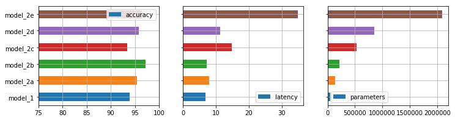

```python
# compare the performance of all model variations
df = pd.DataFrame.from_dict(model_scores, orient='index')
# plot the comparison of models as horizontal bar plot
fig, axes = plt.subplots(ncols=3, figsize=(12,3), sharey=True)
for ax, column in zip(axes, df.columns):
    # for accuracy start x_axis from 75% for easier comparison of the scores
    xlim=[75,100] if column=="accuracy" else None
    df.plot.barh(y=column, ax=ax, grid=True, xlim=xlim)
```

```python
# best_model = input("Enter the best performing model between ['1', '2a','2b','2c','2d','2e'] using the above graphs : ")
# best_model = best_model.lower()
# assert best_model in ['1','2a','2b','2c','2d','2e']
best_model = "2d"

if best_model == "1":
    best_model_params = {"convs":[16,32,64], "kernel_size":3}
elif best_model == "2a":
    best_model_params = {"convs":[32,64], "kernel_size":5}
elif best_model == "2b":
    best_model_params = {"convs":[32,64,128], "kernel_size":3}
elif best_model == "2c":
    best_model_params = {"convs":[64,128], "kernel_size":5}
elif best_model == "2d":
    best_model_params = {"convs":[64,128,256], "kernel_size":3}
elif best_model == "2e":
    best_model_params = {"convs":[128,256], "kernel_size":5}

# reset previous model_scores
model_scores={}
```

## MODEL 3: Regularization of model Testing if L2_norm / Dropout regularization helps the generalization capacity of the model : 1. dropout = 5% and no L2_norm 2. dropout = 10% and no L2 norm 3. dropout = 5% and L2 norm = 0.0001 4. no dropout and L2_norm = 0.001

```
-------------------------------
Training MODEL_3A with L2-norm = 0 and dropout = 5.0%
-------------------------------

Early stopping at epoch 78.
Best validation accuracy = 95.775%
```

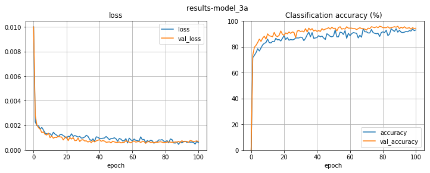

```
-------------------------------
Training MODEL_3B with L2-norm = 0 and dropout = 10.0%
-------------------------------

Early stopping at epoch 73.
Best validation accuracy = 95.035%
```

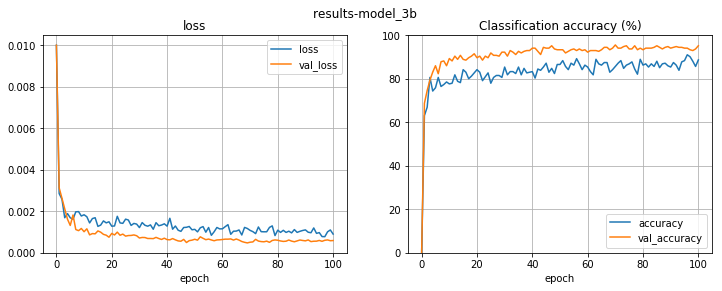

```
-------------------------------
Training MODEL_3C with L2-norm = 0.0001 and dropout = 5.0%
-------------------------------

Early stopping at epoch 81.
Best validation accuracy = 94.485%
```

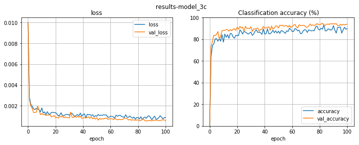

```
-------------------------------
Training MODEL_3D with L2-norm = 0.001 and dropout = 0.0%
-------------------------------

Early stopping at epoch 73.
Best validation accuracy = 91.725%
```

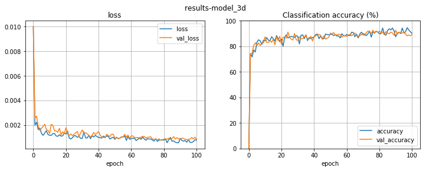

```python
# increasing the patience since models with dropout and regularizers converge much slowly
max_patience=30

# train the models with different L2-norm rates and dropout
for v, l2_norm, dropout in [("a", 0, 0.05), ("b", 0, 0.1), ("c", 1e-4, 0.05),("d", 1e-3, 0.)]:

    # init the model with the dropout
    name = "model_3"+v
    model = FCN(dropout=dropout, **best_model_params).to(device)
    model = model.apply(init_weights)

    # init the trainer helper class
    trainer = Trainer(model, train_set, val_set,
                      batch_size=batch_size, lr=lr, lr_decay_every=lr_decay_every,
                      l2_norm=l2_norm,
                      save_path="results-model_3{}/".format(v),
                      device=device)
    # train
    print("-------------------------------\nTraining {} with L2-norm = {} and dropout = {}%\n-------------------------------\n".format(
        name.upper(), l2_norm, dropout*100))
    best_val_acc = 0
    best_epoch = 0
    patience = 0
    for epoch in range(epochs):
        trainer.train()
        # create a model checkpoint if needed
        cur_val_acc = trainer.results.val_accuracy.iloc[-2:].mean()
        if  cur_val_acc > best_val_acc:
            best_epoch = epoch
            best_val_acc = cur_val_acc
            trainer.save_model("model_best")
            # reset patience
            patience = 0
        else:
            patience += 1
        # early stop if the validation accuracy didnt improve for 5 epochs
        if patience > max_patience:
            break

    model_scores.update({
        name:{
         "accuracy":best_val_acc,
         "parameters":count_parameters(model),
         "latency":trainer.results["epoch duration"].mean(),
        }})

    print("Early stopping at epoch {}. \nBest validation accuracy = {}%".format(
        best_epoch, best_val_acc))
    # at the end plot training curves, save results and model to files
    trainer.end()
```

```python
# compare the performance of all model variations
df = pd.DataFrame.from_dict(model_scores, orient='index')
# plot the comparison of models as horizontal bar plot
df.plot.barh(y="accuracy", ax=ax, grid=True, xlim=[75,100])
plt.show()
```

[output not shown]

## Analysis of Model 3 (regularizations) The L2_norm regularization seems to be counter productive and leads to a ~2% drop in generalization accuracy. The dropout based networks perform almost similar. The configuration MODEL_3A with **dropout=5%** and **no L2_norm** has one of the best generalization score (moving-average validation accuracy) while the training curve for training and test data are more closer. From the training curves, it can be observed that the regularizations prevents the model from overfitting easily. Even though regularizations can be seen to slightly lower the training accuracy, they are known to improve the ability of the network to generalize better. Therefore, they are expected to improve the accuracy on the test_split.

```python
# best_model = input("Enter the best performing model between ['3a','3b','3c','3d'] using the above graphs : ")
# best_model = best_model.lower()
best_model = '3a'
```

## Final evaluation on test set (The below cells are executed only once all the hyperparameters are fixed)

```python
model = torch.load("results-model_{}/model_best.pt".format(best_model))

test_loader = torch.utils.data.DataLoader(test_set, batch_size=batch_size)

model.eval()

loss=0
acc=0
n=0
# validate on validation split
with torch.no_grad():
    for images, labels in test_loader:
        images = images.to(device)
        labels = labels.to(device)
        preds = model(images)
        l = F.cross_entropy(preds, labels)

        loss =+ l.item()
        acc =+ trainer.equals(preds, labels)
        n =+ len(images)


loss = loss/n
acc = round(100*acc/n,2) # in percentage
print("Final Test accuracy = {}%".format(acc))
```

```
Final Test accuracy = 94.12%
```

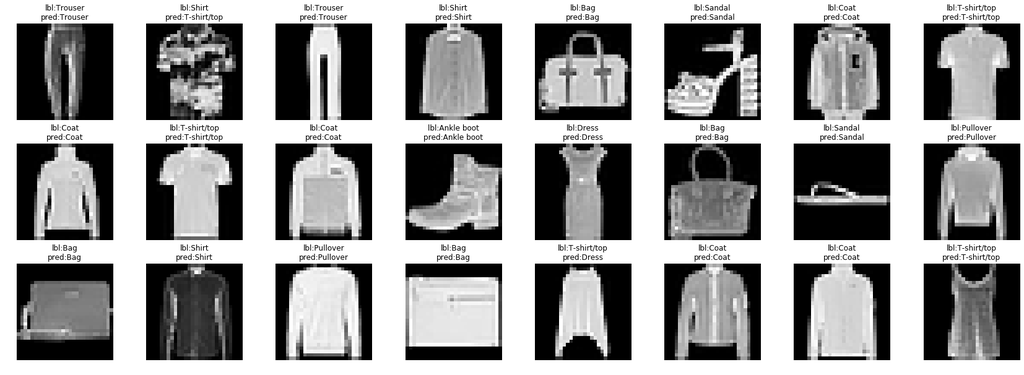

```python
# convert the last batch of images from the test set to a numpy array of 2D images
images_ =  images.cpu().numpy()[:,0,:,:]
labels_ = labels.cpu().numpy()
preds_ = preds.argmax(dim=1).cpu().numpy()

# visualize some predictions
fig, axes = plt.subplots(nrows=3, ncols=8, figsize=(30,10))

for i, ax in enumerate(axes.reshape(-1)):
    ax.imshow(images_[i], cmap="gray")
    ax.set_title("lbl:{}\npred:{}".format(label_names[labels_[i]], label_names[preds_[i]]))
    ax.axis("off")

plt.subplots_adjust(wspace=0., hspace=0.25)
plt.show()
```